# Assignment03

Odiche Nwabuikwu

2/8/2020

```r
library(tidyverse)
library(waffle)
library(urbnthemes)
set_urbn_defaults(style = "print")
```

```r
sex <- read_csv('data/EducationDataPortal_02.07.2020_sex.csv')
study <- read_csv('data/EducationDataPortal_02.07.2020_level_of_study.csv')
inst <- read_csv('data/EducationDataPortal_02.13.2020_institutions.csv')
ftpt <- read_csv('data/EducationDataPortal_02.12.2020_ftpt.csv')
```

```r
# ftpt
# reshape
ftpt <- pivot_wider(data = ftpt, names_from = ftpt, values_from = retention_rate)

# remove missing values AND make states categorical vars
ftpt <- ftpt %>%
  filter(!is.na('state_name'), !is.na(`Full-time`), !is.na(`Part-time`)) %>%
  mutate(state_name = factor(state_name, levels = c("California", "Florida", "New York",
                                                    "Pennsylvania", "Texas"))) %>%
  select(-`Part-time`, -Total)

# sex
sex <- sex %>%
  filter(sex != 'Total') %>%
  filter(!is.na(number_applied)) %>%
  select(-number_admitted)

# reshape - num applied
sex <- pivot_wider(data = sex, names_from = sex,
                   values_from = number_applied)


# study
study <- study %>%
  filter(!is.na(enrollment_fall),
                level_of_study != 'Graduate') %>%
  select(-level_of_study)

# inst
# remove character and missing values from percent variable
inst <-inst %>%
  filter(!grepl("[a-z]", inst$lowincome_pct)) %>%
  filter(!is.na(lowincome_pct))

# merge datasets
ed_data <- left_join(ftpt, inst)
ed_data <- full_join(ed_data, sex)
ed_data <- full_join(ed_data, study)


rm(ftpt, inst, sex, study)
```

My dataset was obtained from the Urban Institute, and contains data on tertiary institutions in California, Texas, Pennsylvania, New York and Florida. I chose these states because of their high volume of tertiary institutions. I also chose to use data from 2003 to 2013 beause I was interested in the behavior of these tertiary institutions during the 2008 Financial Crisis.

My first visualization is a line-plot showing the full-time student retention rates for U.S. tertiary institutions from 2003 to 2013. In particular, I wanted to examine how average retention rates changed after the 2008 Recession. Overall, the plot shows a decrease in retention rates for California, New York, Pennsylvania and Texas around 2007 to 2010. However, retention rates in Florida show an overall increase, which is unexpected.

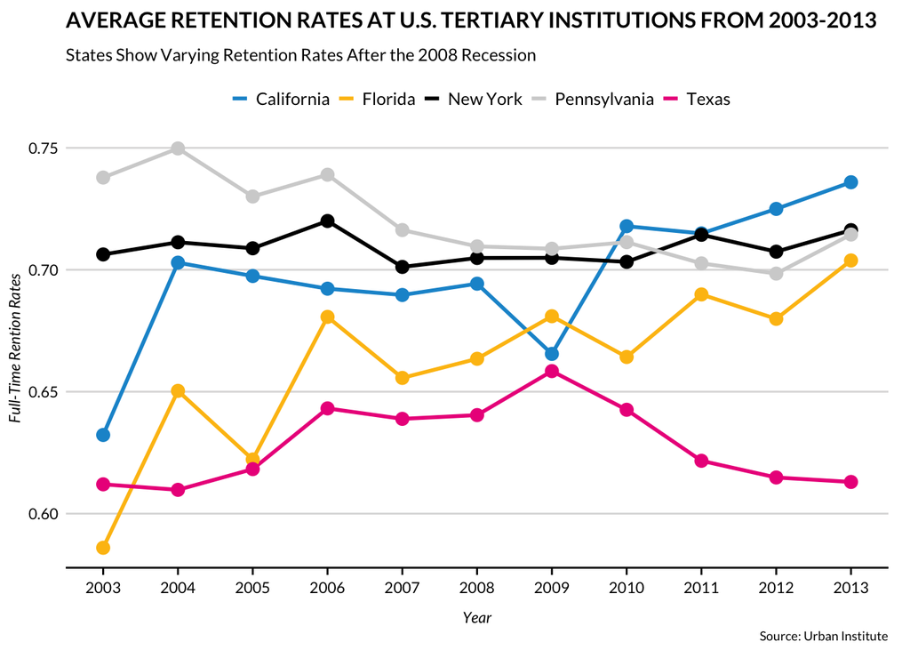

```r
## 1st graph

# collapse by state and year to get mean retention rates
ftpt <- ed_data %>%
  group_by(state_name, year) %>%
  summarize(reten_full = mean(`Full-time`, na.rm = TRUE))

# line graph
ggplot(data = ftpt) +
  geom_line(mapping = aes(x = year, y = `reten_full`, color = state_name)) +
  geom_point(mapping = aes(x = year, y = `reten_full`, color = state_name), show.legend = FALSE) +
  scale_x_continuous(breaks = seq(2003, 2013, 1), limits = c(2003, 2013)) +
  labs(title = "AVERAGE RETENTION RATES AT U.S. TERTIARY INSTITUTIONS FROM 2003-2013",
       subtitle = "States Show Varying Retention Rates After the 2008 Recession",
       caption = "Source: Urban Institute",
       x = "Year",
       y = "Full-Time Rention Rates")
```

My second visualization is a stacked bar chart showing the breakdown of male and female undergraduate applications to Californian universities. I was interested in seeing whether this distribution changed during the financial crisis. Overall, the graph shows a steady increase in applications. The share of men and women in each cohort also appears to be constant.

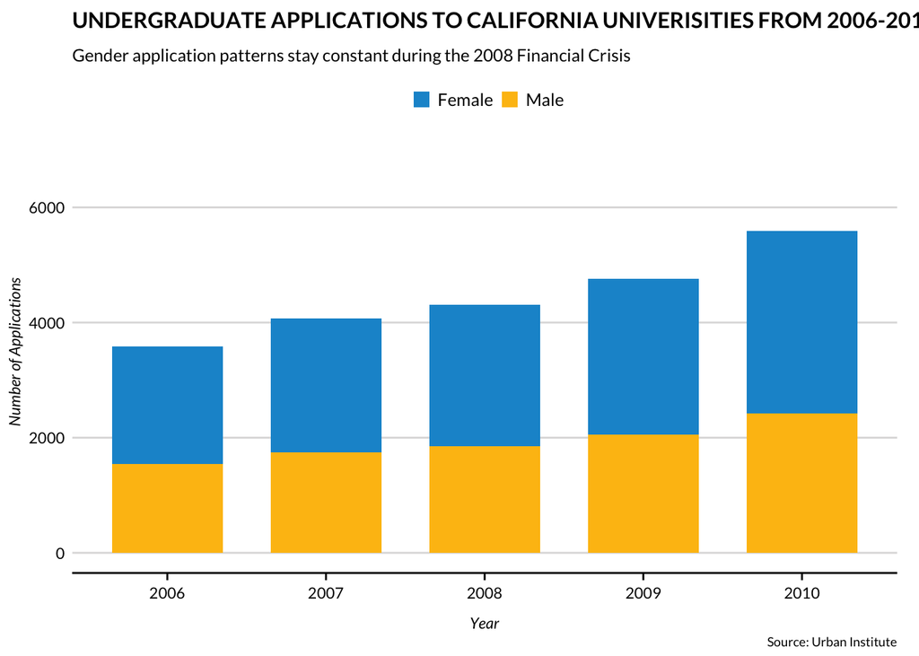

```r
# 2nd graph

sex <- ed_data %>%
  filter(year %in% c(2006:2010)) %>%
  select(-`Full-time`, -enrollment_fall, -state_abbr, -lowincome_pct) %>%
  pivot_longer(cols = c(-year, -unitid, -inst_name, -state_name),
               names_to = "sex", values_to = "number_applied") %>%
  filter(!is.na(number_applied)) %>%
  distinct() %>%
  filter(state_name %in% c("California"))

# group by sex and year to make bar chart
sex <- sex %>%
  group_by(year, sex) %>%
summarize(count_app = mean(number_applied))


ggplot(data = sex,
       mapping = aes(fill = sex, y = count_app, x = factor(year))) +
  geom_bar(position = "stack", stat="identity") +
  scale_y_continuous(breaks = seq(0, 8000, 2000), lim = c(0, 7000)) +
  labs(title =
        paste("UNDERGRADUATE APPLICATIONS TO CALIFORNIA",
        "UNIVERISITIES FROM 2006-2010"),
       subtitle = "Gender application patterns stay constant during the 2008 Financial Crisis",
       caption = "Source: Urban Institute",
       x = "Year",
       y = "Number of Applications")
```

My third visualization is a waffle chart showing the share of undergraduate enrollment for 2007. Californian schools appear to have the highest enrollment number by far.

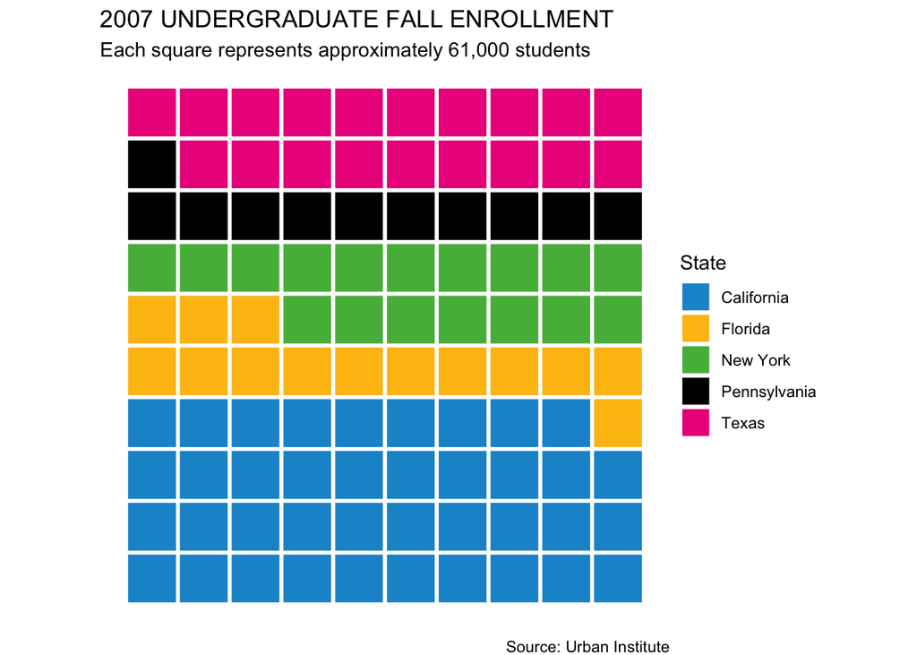

```r
# 3rd graph

study <- ed_data %>%
  filter(!is.na(enrollment_fall),
         year == 2007)

study %>%
  group_by(state_name) %>%
  summarize(enrol = sum(enrollment_fall)) %>%
  ggplot(aes(fill = state_name, values = enrol)) +
  geom_waffle(n_rows = 10, size = 1, colour = "white",
              flip = TRUE, make_proportional = TRUE) +
  coord_equal() +
  scale_fill_manual(name = "State",
                    values = c("#1696d2", "#fdbf11", "#55b748", "#000000", "#ec008b")) +
  theme_void() +
  theme(panel.grid.major = element_blank(), panel.grid.minor = element_blank()) +
  theme(axis.text.x = element_blank(),
        axis.text.y = element_blank(),
        axis.ticks = element_blank()) +
  labs(title = "2007 UNDERGRADUATE FALL ENROLLMENT",
       subtitle = "Each square represents approximately 61,000 students",
       caption = "Source: Urban Institute")
```

My fourth visualization shows the relationship between full-time retention rates and the share of low income students on financial aid in New York universities. The data shows a slight negative relationship between retention rates and the share of low-income students. This data supports my reasoning that higher retention rates are associated with lower percentage of aid given to low-income students, because schools are paying more as a result of students staying longer. I theorized that this negative relationship would become sharper during the financial crisis, but this does not appear to be the case.

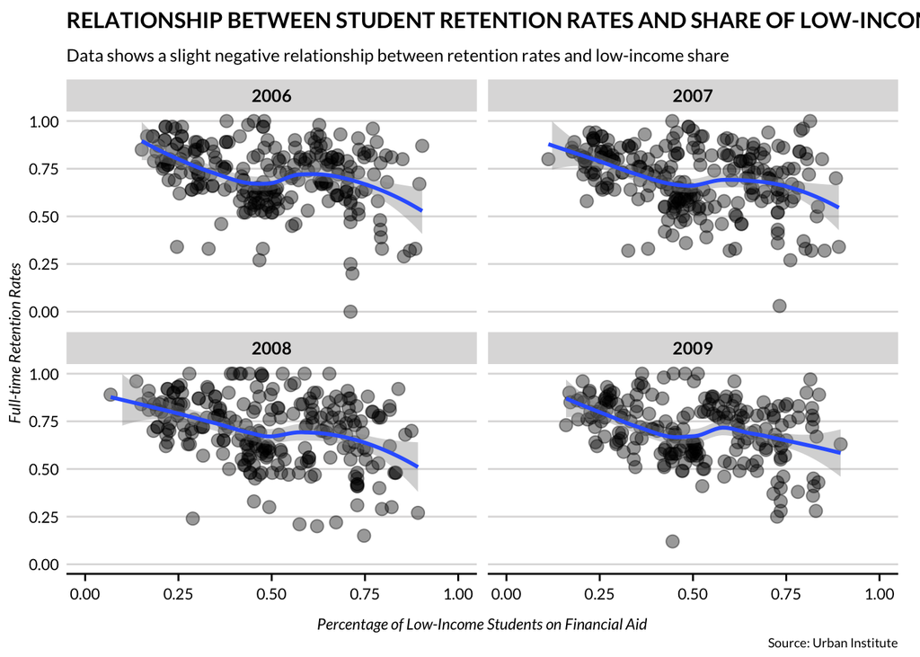

```r
# 4th graph

# inst
inst <- ed_data %>%
  filter(!is.na(lowincome_pct)) %>%
  filter(!grepl("[a-z]", lowincome_pct)) %>%
  mutate(lowincome_pct = as.numeric(lowincome_pct)) %>%
  filter(year %in% c(2006:2009),
         state_name %in% c('New York'))

ggplot(data = inst,
       mapping = aes(x = lowincome_pct, y = `Full-time`)) +
    geom_point(color = "#000000", alpha = 0.4) +
  facet_wrap(~year, ncol = 2) +
  geom_smooth() +
  scale_y_continuous(limits = c(0, 1),
                     breaks = seq(0, 1, 0.25)) +
  scale_x_continuous(limits = c(0, 1),
                     breaks = seq(0, 1, 0.25)) +
  labs(title =
      paste("RELATIONSHIP BETWEEN STUDENT RETENTION RATES AND SHARE OF LOW-INCOME STUDENTS"),
      ("IN NEW YORK UNIVERSITIES"),
       subtitle = "Data shows a slight negative relationship between retention rates and low-income share",
      caption = "Source: Urban Institute",
      x = "Percentage of Low-Income Students on Financial Aid",
      y = "Full-time Retention Rates")
```